# FML Assignment 5

```r
print(hc_complete$ac)
```

```
## [1] 0.8353712
```

```r
print(hc_average$ac)
```

```
## [1] 0.7766075
```

```r
print(hc_Ward$ac)
```

```
## [1] 0.9046042
```

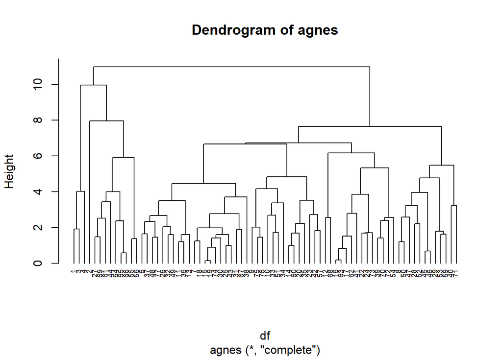

```r
pltree(hc_complete, cex=0.6, hang =-1, main = "Dendrogram of agnes")
```

# Explanation -From the above output the best value we got is 0.904. Plotting the Dendrogram.

#Using elbow method

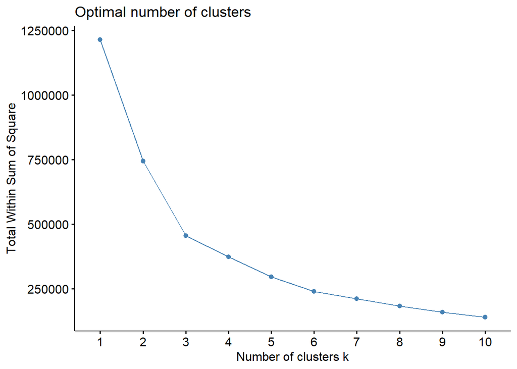

```r
set.seed(123)
fviz_nbclust(Cereals_1_, FUN = hcut, method = "wss")
```

#2.Choosing the cluster

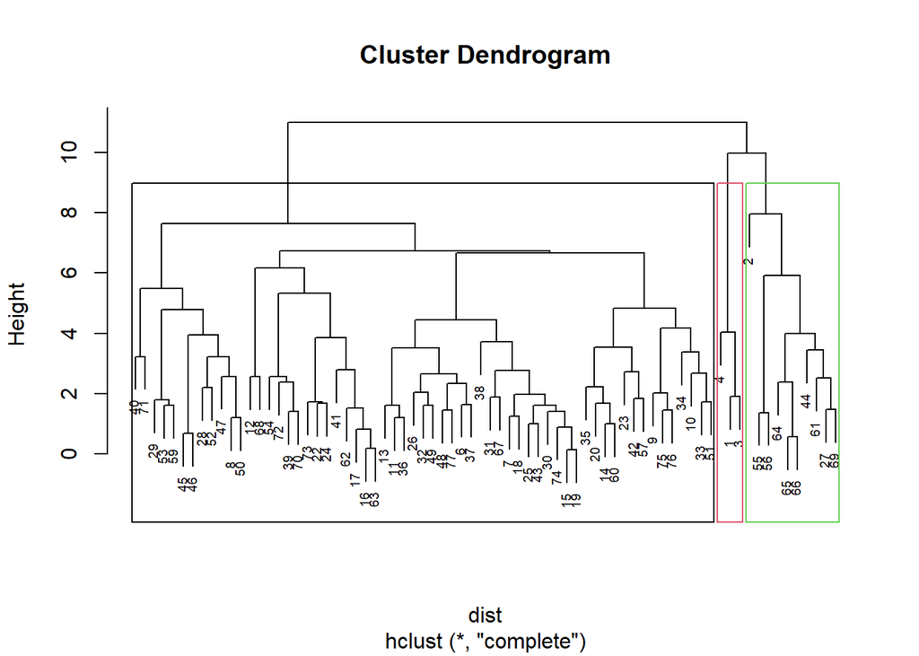

```r
dist <- dist(df, method = "euclidean")
H_clustering <- hclust(dist, method = "complete")
#Complete divisive hierarchical clustering

plot(H_clustering, cex=0.6)
rect.hclust(H_clustering, k=3, border = 1:4)
```

```r
Cluster1 <- cutree(hc_Ward, k=3)
dataframe2 <- as.data.frame(cbind(df,Cluster1))
```

#Comment- Thus from the above methods we can confirm that the number of cluster ideal for the dataset is 3. Hence the value for k=3

#3.Creating Partitions

```r
set.seed(123)
PartitionA <- df[1:50,]
PartitionB <- df[51:74,]
```

#Performing hierarchical Clustering,consedering k = 3.

```r
single <- agnes(scale(PartitionA), method = "single")

complete <- agnes(scale(PartitionA), method = "complete")

average <- agnes(scale(PartitionA), method = "average")

ward <- agnes(scale(PartitionA), method = "ward")
```

```r
cbind(single=single$ac , complete=complete$ac , average= average$ac , ward= ward$ac)
```

```
##         single  complete   average      ward
## [1,] 0.6393338 0.8138238 0.7408904 0.8764323
```

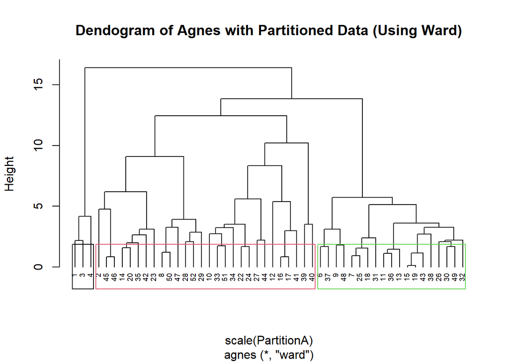

```r
pltree(ward, cex = 0.6, hang = -1, main = "Dendogram of Agnes with Partitioned Data (Using Ward)")
rect.hclust(ward, k = 3, border = 1:4)
```

```r
cut_2 <- cutree(ward, k = 3)
```

#Calculating the centeroids

```r
result <- as.data.frame(cbind(PartitionA, cut_2))
result[result$cut_2==1,]
```

```
##    calories  protein        fat     sodium    fiber     carbo     sugars
## 1 -1.865915 1.381748  0.0000000 -0.3910227 3.228667 -2.500140 -0.2542051
## 3 -1.865915 1.381748  0.0000000  1.1795987 2.816023 -1.986222 -0.4836096
## 4 -2.873782 1.381748 -0.9932203 -0.2702057 4.879247 -1.729263 -1.6306324
##     potass   vitamins     shelf     weight      cups   rating cut_2
## 1 2.560523 -0.1818422 0.9419715 -0.2008324 -2.085658 1.854904     1
## 3 3.124867 -0.1818422 0.9419715 -0.2008324 -2.085658 1.215196     1
## 4 3.265954 -0.1818422 0.9419715 -0.2008324 -1.364449 3.657844     1
```

```r
c1 <- colMeans(result[result$cut_2==1,])
result[result$cut_2==2,]
```

```
##      calories    protein        fat      sodium       fiber       carbo
## 2   0.6537514  0.4522084  3.9728810 -1.78041856 -0.07249167 -1.72926320
## 8   1.1576848  0.4522084  0.9932203  0.57551356 -0.07249167  0.84032469
## 10 -0.8580487  0.4522084 -0.9932203  0.57551356  1.16544301 -0.44446926
## 12  0.1498180  3.2408266  0.9932203  1.54204982 -0.07249167  0.58336590
## 14  0.1498180  0.4522084  0.9932203 -0.27020566 -0.07249167 -0.44446926
## 16  0.1498180 -0.4773310 -0.9932203  1.42123279 -0.89778146  1.86815984
## 17 -0.3541153 -0.4773310 -0.9932203  1.54204982 -0.48513656  1.61120105
## 20  0.1498180  0.4522084  1.9864405 -0.27020566  0.75279812 -1.21534562
## 22  0.1498180 -0.4773310 -0.9932203  0.69633060 -0.48513656  1.61120105
## 23 -0.3541153 -0.4773310  0.0000000 -0.27020566 -0.07249167 -0.95838683
## 24 -0.3541153 -0.4773310 -0.9932203  0.33387950 -0.48513656  0.84032469
## 27 -0.3541153  0.4522084 -0.9932203 -1.96164410  0.34015322 -0.18751047
## 28  0.6537514  0.4522084  0.9932203 -0.02857160  1.16544301 -0.70142805
## 29  0.6537514  0.4522084 -0.9932203  0.93796466  1.16544301 -0.18751047
```

[output cut: 72 more lines]

```r
c2 <- colMeans(result[result$cut_2==2,])
result[result$cut_2==3,]
```

```
##      calories    protein        fat     sodium       fiber       carbo
## 6   0.1498180 -0.4773310  0.9932203  0.2130625 -0.27881412 -1.08686623
## 7   0.1498180 -0.4773310 -0.9932203 -0.4514312 -0.48513656 -0.95838683
## 9  -0.8580487 -0.4773310  0.0000000  0.4546965  0.75279812  0.06944832
## 11  0.6537514 -1.4068705  0.9932203  0.6963306 -0.89778146 -0.70142805
## 13  0.6537514 -1.4068705  1.9864405  0.5755136 -0.89778146 -0.44446926
## 15  0.1498180 -1.4068705  0.0000000  0.2130625 -0.89778146 -0.70142805
## 18  0.1498180 -1.4068705 -0.9932203 -0.8742908 -0.48513656 -0.44446926
## 19  0.1498180 -1.4068705  0.0000000  0.2130625 -0.89778146 -0.70142805
## 25  0.1498180 -0.4773310  0.0000000 -0.4514312 -0.48513656 -0.95838683
## 26  0.1498180 -1.4068705 -0.9932203  0.4546965 -0.48513656 -0.18751047
## 30  0.1498180 -1.4068705  0.0000000 -0.3306142 -0.89778146 -0.44446926
## 31 -0.3541153 -0.4773310 -0.9932203 -1.4179675 -0.89778146 -0.95838683
## 32  0.1498180 -1.4068705  0.0000000  1.4212328 -0.89778146  0.06944832
## 36  0.6537514 -1.4068705  0.9932203  0.6963306 -0.48513656 -0.70142805
```

[output cut: 45 more lines]

```r
c3 <- colMeans(result[result$cut_2==3,])
result[result$cut_2==4,]
```

```
##  [1] calories protein  fat      sodium   fiber    carbo    sugars   potass
##  [9] vitamins shelf    weight   cups     rating   cut_2
## <0 rows> (or 0-length row.names)
```

```r
c4 <- colMeans(result[result$cut_2==4,])

centroids <- rbind(c1, c2, c3, c4)
bind <- as.data.frame(rbind(centroids[,-14], PartitionB))
```

#Calculating the Distance

```r
D <- dist(bind)
Matrix_1 <- as.matrix(D)

dataframe1 <- data.frame(data=seq(1,nrow(PartitionB),1), Clusters = rep(0,nrow(PartitionB)))
for(i in 1:nrow(PartitionB))
{dataframe1[i,2] <- which.min(Matrix_1[i+4, 1:4])}
dataframe1
```

```
##    data Clusters
## 1     1        2
## 2     2        2
## 3     3        3
## 4     4        2
## 5     5        2
## 6     6        2
## 7     7        2
## 8     8        2
## 9     9        3
## 10   10        3
## 11   11        2
## 12   12        2
## 13   13        2
## 14   14        3
## 15   15        2
## 16   16        2
## 17   17        2
## 18   18        2
## 19   19        2
## 20   20        2
## 21   21        3
## 22   22        2
## 23   23        2
## 24   24        3
```

```r
cbind(dataframe2$Cluster1[51:74], dataframe1$Clusters)
```

```
##       [,1] [,2]
##  [1,]    1    2
##  [2,]    3    2
##  [3,]    3    3
##  [4,]    3    2
##  [5,]    1    2
##  [6,]    1    2
##  [7,]    1    2
##  [8,]    3    2
##  [9,]    3    3
## [10,]    3    3
## [11,]    3    2
## [12,]    3    2
## [13,]    3    2
## [14,]    2    3
## [15,]    3    2
## [16,]    3    2
## [17,]    3    2
## [18,]    1    2
## [19,]    3    2
## [20,]    3    2
## [21,]    2    3
## [22,]    3    2
## [23,]    3    2
## [24,]    2    3
```

```r
table(dataframe2$Cluster1[51:74] == dataframe1$Clusters)
```

```
##
## FALSE  TRUE
##    21     3
```

#4) The elementary public schools would like to choose a set of Cereals_Data to include in their daily cafeterias.

```r
HCereals <- Cereals_1_
HCereals_new <- na.omit(HCereals)
HClust <- cbind(HCereals_new, Cluster1)
HClust[HClust$Cluster1==1,]
```

```
##                                      name mfr type calories protein fat sodium
## 1                               100%_Bran   N    C       70       4   1    130
## 2                       100%_Natural_Bran   Q    C      120       3   5     15
## 3                                All-Bran   K    C       70       4   1    260
## 4               All-Bran_with_Extra_Fiber   K    C       50       4   0    140
## 8                                 Basic_4   G    C      130       3   2    210
## 14                               Clusters   G    C      110       3   2    140
## 20                     Cracklin'_Oat_Bran   K    C      110       3   3    140
## 23                 Crispy_Wheat_&_Raisins   G    C      100       2   1    140
## 28 Fruit_&_Fibre_Dates,_Walnuts,_and_Oats   P    C      120       3   2    160
## 29                          Fruitful_Bran   K    C      120       3   0    240
## 35                     Great_Grains_Pecan   P    C      120       3   3     75
## 40                 Just_Right_Fruit_&_Nut   K    C      140       3   1    170
## 42                                   Life   Q    C      100       4   2    150
## 45       Muesli_Raisins,_Dates,_&_Almonds   R    C      150       4   3     95
```

[output cut: 33 more lines]

```r
HClust[HClust$Cluster1==2,]
```

```
##                       name mfr type calories protein fat sodium fiber carbo
## 6  Apple_Cinnamon_Cheerios   G    C      110       2   2    180   1.5  10.5
## 7              Apple_Jacks   K    C      110       2   0    125   1.0  11.0
## 11            Cap'n'Crunch   Q    C      120       1   2    220   0.0  12.0
## 13   Cinnamon_Toast_Crunch   G    C      120       1   3    210   0.0  13.0
## 15             Cocoa_Puffs   G    C      110       1   1    180   0.0  12.0
## 18               Corn_Pops   K    C      110       1   0     90   1.0  13.0
## 19           Count_Chocula   G    C      110       1   1    180   0.0  12.0
## 25             Froot_Loops   K    C      110       2   1    125   1.0  11.0
## 26          Frosted_Flakes   K    C      110       1   0    200   1.0  14.0
## 30          Fruity_Pebbles   P    C      110       1   1    135   0.0  13.0
## 31            Golden_Crisp   P    C      100       2   0     45   0.0  11.0
## 32          Golden_Grahams   G    C      110       1   1    280   0.0  15.0
## 36        Honey_Graham_Ohs   Q    C      120       1   2    220   1.0  12.0
## 37      Honey_Nut_Cheerios   G    C      110       3   1    250   1.5  11.5
```

[output cut: 29 more lines]

```r
HClust[HClust$Cluster1==3,]
```

```
##                           name mfr type calories protein fat sodium fiber carbo
## 9                    Bran_Chex   R    C       90       2   1    200     4    15
## 10                 Bran_Flakes   P    C       90       3   0    210     5    13
## 12                    Cheerios   G    C      110       6   2    290     2    17
## 16                   Corn_Chex   R    C      110       2   0    280     0    22
## 17                 Corn_Flakes   K    C      100       2   0    290     1    21
## 22                     Crispix   K    C      110       2   0    220     1    21
## 24                 Double_Chex   R    C      100       2   0    190     1    18
## 27         Frosted_Mini-Wheats   K    C      100       3   0      0     3    14
## 33           Grape_Nuts_Flakes   P    C      100       3   1    140     3    15
## 34                  Grape-Nuts   P    C      110       3   0    170     3    17
## 39 Just_Right_Crunchy__Nuggets   K    C      110       2   1    170     1    17
## 41                         Kix   G    C      110       2   1    260     0    21
## 44                       Maypo   A    H      100       4   1      0     0    16
## 51           Nutri-grain_Wheat   K    C       90       3   0    170     3    18
```

[output cut: 47 more lines]

```r
HClust[HClust$Cluster1==4,]
```

```
##  [1] name     mfr      type     calories protein  fat      sodium   fiber
##  [9] carbo    sugars   potass   vitamins shelf    weight   cups     rating
## [17] Cluster1
## <0 rows> (or 0-length row.names)
```

```r
#Mean ratings to determine the best cluster.
mean(HClust[HClust$Cluster1==1,"rating"])
```

```
## [1] 42.90285
```

```r
mean(HClust[HClust$Cluster1==2,"rating"])
```

```
## [1] 28.84825
```

```r
mean(HClust[HClust$Cluster1==3,"rating"])
```

```
## [1] 51.43111
```

```r
mean(HClust[HClust$Cluster1==4,"rating"])
```

```
## [1] NaN
```